# HW11: Education Level and Survey Weighting

Lucy Scothern

# Introduction

In this assignment, you’ll examine how survey weighting affects our understanding of voting intentions across different education levels, using the data we examined in class. You’ll calculate both weighted and unweighted statistics, create visualizations, and reflect on the implications for reporting.

## The Data

The nonvoters dataset contains survey responses about voting intentions and behaviors from a national survey. The survey was conducted prior to an election and includes demographic information like education level.

```r
# Load the dataset
nonvoters_data <- read_csv("https://raw.githubusercontent.com/dwillis/jour405_files/refs/heads/main/nonvoters_data.csv")

# Take a quick look at the data structure
glimpse(nonvoters_data)
```

```
## Rows: 5,836
## Columns: 119
## $ RespId         <dbl> 470001, 470002, 470003, 470007, 480008, 480009, 480010,…
## $ weight         <dbl> 0.7516, 1.0267, 1.0844, 0.6817, 0.9910, 1.0591, 1.1512,…
## $ Q1             <dbl> 1, 1, 1, 1, 1, 1, 1, 1, 1, 1, 1, 1, 1, 1, 1, 1, 1, 1, 1…
## $ Q2_1           <dbl> 1, 1, 1, 1, 1, 3, 1, 1, 1, 1, 1, 1, 3, 1, 1, 1, 1, 1, 1…
## $ Q2_2           <dbl> 1, 2, 1, 1, 1, 2, 1, 1, 1, 1, 2, 1, 4, 1, 1, 1, 1, 1, 1…
## $ Q2_3           <dbl> 2, 2, 2, 1, -1, 3, 2, 2, 1, 2, 2, 1, 2, 3, 1, 1, 1, 1, …
## $ Q2_4           <dbl> 4, 3, 2, 3, 1, 4, 3, 2, 3, 1, 2, 4, 2, 3, 1, 1, 1, 1, 2…
## $ Q2_5           <dbl> 1, 1, 1, 1, 1, 1, 1, 1, 1, 1, 2, 1, 4, 1, 1, 1, 1, 1, 1…
## $ Q2_6           <dbl> 4, 1, 1, 1, 1, 3, 1, 3, 1, 1, 2, 4, 2, 1, 1, 1, 1, 1, 2…
## $ Q2_7           <dbl> 2, 2, 2, 1, 1, 3, 1, 1, 1, 1, 2, 2, 1, 1, 1, 1, 1, 1, 1…
## $ Q2_8           <dbl> 2, 1, 1, 1, 1, 1, 1, 1, 1, 2, 2, 3, 2, 1, 1, 1, 1, 2, 1…
## $ Q2_9           <dbl> 4, 1, 4, 1, 1, 1, 1, 4, 3, 1, 3, 4, 4, 4, 1, 1, 2, 1, 3…
## $ Q2_10          <dbl> 2, 3, 3, 2, 1, 4, 3, 2, 2, 2, 3, 2, 2, 3, 4, 2, 1, 1, 1…
```

[output cut: 106 more lines]

### Key Variables

- `weight`: Survey weight assigned to each respondent
- `Q21`: Voting intention (1 = Yes, 2 = No, 3 = Unsure/Undecided)
- `educ`: Education level (College, Some college, High school or less)

## Task 1: Education Distribution

First, let’s examine the distribution of education levels in our sample. Replace “REPLACE_ME” with the correct variable for education level.

```r
education_distribution <- nonvoters_data |>
  count(educ) |>
  mutate(percentage = n / sum(n) * 100) |>
  kable(digits = 1, col.names = c("Education Level", "Count", "Percentage (%)"))

education_distribution
```

| Education Level | Count | Percentage (%) |
| --- | --- | --- |
| College | 2330 | 39.9 |
| High school or less | 1796 | 30.8 |
| Some college | 1710 | 29.3 |

## Task 2: Reflection Question

Why might education levels in survey samples often differ from the general population? What factors might cause certain education groups to be over or underrepresented?

Typically people with a higher level of education access and fill out surveys, so that group will likely be over represented.

## Task 3: Unweighted Analysis by Education

Now, let’s calculate unweighted voting intentions by education level. This is what we would report if we didn’t apply any weighting to our sample.

```r
# Calculate unweighted voting intentions by education
unweighted_by_education <- nonvoters_data |>
  # Filter out missing values
  filter(!is.na(Q21), Q21 > 0, !is.na(educ)) |>
  # Group by education and response
  group_by(educ, Q21) |>
  # Count responses
  summarize(count = n(), .groups = "drop_last") |>
  # Calculate percentages
  mutate(total = sum(count),
         percentage = count / total * 100) |>
  ungroup()

# Create a more readable format with voting intentions as columns
unweighted_educ_summary <- unweighted_by_education |>
  pivot_wider(
    id_cols = educ,
    names_from = Q21,
    values_from = percentage,
    names_prefix = "pct_"
  ) |>
  rename(
    "Yes (%)" = pct_1,
    "No (%)" = pct_2,
    "Unsure (%)" = pct_3
  )

kable(unweighted_educ_summary, digits = 1, caption = "Unweighted Voting Intentions by Education Level")
```

Unweighted Voting Intentions by Education Level

| educ | Yes (%) | No (%) | Unsure (%) |
| --- | --- | --- | --- |
| College | 93.4 | 3.4 | 3.2 |
| High school or less | 73.5 | 14.6 | 11.9 |
| Some college | 85.7 | 7.4 | 6.9 |

## Task 4: Reflection Question

Based just on this unweighted analysis, what headline might you write for a news story about education and voting intentions?

New Survey shows college-educated individuals are more likely to vote compared to those with lower education levels.

## Task 5: Weighted Analysis by Education

Next, let’s apply survey weights to see how this changes our results. Instead of just counting responses, we’ll sum the weights for each group. Replace “REPLACE_ME” with the appropriate weight variable

```r
weighted_by_education <- nonvoters_data |>
  # Filter out missing values
  filter(!is.na(Q21), Q21 > 0, !is.na(educ)) |>
  # Group by education and response
  group_by(educ, Q21) |>
  # Sum the weights instead of counting
  summarize(weighted_count = sum(weight), .groups = "drop_last") |>
  # Calculate weighted percentages
  mutate(weighted_total = sum(weighted_count),
         weighted_percentage = weighted_count / weighted_total * 100) |>
  ungroup()

# Create a more readable format
weighted_educ_summary <- weighted_by_education |>
  pivot_wider(
    id_cols = educ,
    names_from = Q21,
    values_from = weighted_percentage,
    names_prefix = "pct_"
  ) |>
  rename(
    "Yes (%)" = pct_1,
    "No (%)" = pct_2,
    "Unsure (%)" = pct_3
  )

kable(weighted_educ_summary, digits = 1, caption = "Weighted Voting Intentions by Education Level")
```

Weighted Voting Intentions by Education Level

| educ | Yes (%) | No (%) | Unsure (%) |
| --- | --- | --- | --- |
| College | 93.5 | 3.2 | 3.3 |
| High school or less | 70.8 | 16.1 | 13.2 |
| Some college | 85.1 | 7.8 | 7.2 |

## Task 6: Reflection Questions

1. How did the percentages change after applying weights? Which education group showed the biggest changes?

2. Why might the weighted results be considered more accurate than the unweighted results?

Weighted results are more accurate because they adjust the sample to better reflect the real population, correcting over/under representation.

## Task 7: Comparison of Weighted vs. Unweighted Results

Let’s create a direct comparison table to see the differences more clearly.

```r
comparison <- unweighted_educ_summary |>
  inner_join(weighted_educ_summary, by = "educ", suffix = c("_unweighted", "_weighted")) |>
  mutate(
    # Calculate the differences between weighted and unweighted percentages
    yes_diff = `Yes (%)_weighted` - `Yes (%)_unweighted`,
    no_diff = `No (%)_weighted` - `No (%)_unweighted`,
    unsure_diff = `Unsure (%)_weighted` - `Unsure (%)_unweighted`
  ) |>
  # Select just the columns we want to display
  select(educ, yes_diff, no_diff, unsure_diff) |>
  rename(
    "Education Level" = educ,
    "Yes (% point diff)" = yes_diff,
    "No (% point diff)" = no_diff,
    "Unsure (% point diff)" = unsure_diff
  )

kable(comparison, digits = 1, caption = "Difference Between Weighted and Unweighted Results (percentage points)")
```

Difference Between Weighted and Unweighted Results (percentage points)

| Education Level | Yes (% point diff) | No (% point diff) | Unsure (% point diff) |
| --- | --- | --- | --- |
| College | 0.1 | -0.1 | 0.1 |
| High school or less | -2.7 | 1.5 | 1.3 |
| Some college | -0.7 | 0.4 | 0.3 |

## Task 8: Reflection Question

Which education group shows the largest differences between weighted and unweighted results?

The highschool or less group.

## Task 9: Visualization

Visualizations can help us see the differences more clearly. Let’s create a bar chart comparing weighted and unweighted “Yes” responses by education level. Replace “REPLACE_ME” with the correct variable name

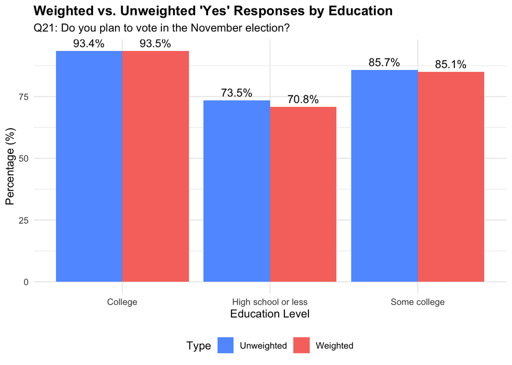

```r
educ_viz_data <- bind_rows(
  # Unweighted data
  unweighted_by_education |>
    filter(Q21 == 1) |>  # Only "Yes" responses (Q21=1)
    mutate(Type = "Unweighted") |>
    select(Type, educ, percentage),

  # Weighted data -
  weighted_by_education |>
    filter(Q21 == 1) |>  # Only "Yes" responses
    mutate(
      Type = "Weighted",
      percentage = weighted_percentage
    ) |>
    select(Type, educ, percentage)
)

# Create a grouped bar chart
ggplot(educ_viz_data,
       aes(x = educ, y = percentage, fill = Type)) +
  geom_bar(stat = "identity", position = "dodge") +
  geom_text(aes(label = sprintf("%.1f%%", percentage)),
            position = position_dodge(width = 0.9), vjust = -0.5) +
  labs(
    title = "Weighted vs. Unweighted 'Yes' Responses by Education",
    subtitle = "Q21: Do you plan to vote in the November election?",
    y = "Percentage (%)",
    x = "Education Level"
  ) +
  scale_fill_manual(values = c("Unweighted" = "#619CFF", "Weighted" = "#F8766D")) +
  theme_minimal() +
  theme(
    plot.title = element_text(face = "bold"),
    legend.position = "bottom"
  )
```

## Task 10: Reflection Questions

Does the visualization make it easier to see the differences between weighted and unweighted results? Why or why not?

Yes visualization does make it easier to see because the bars allow for a side by side comparison.

## Task 11: Summary

Based on your analysis of weighted and unweighted results by education level, write a brief (2-3 paragraph) journalistic summary of what you found. You should try to address:

1. How education level relates to voting intentions
2. How weighting affected your understanding of this relationship
3. What this means for interpreting polling results in news reporting

Education level is strongly linked to voting intentions with college-educated respondents showing the highest likelihood of planning to vote. Those who completed some college, also ranked higher than their highschool educated counterparts showing a clear pattern: as education level increases, so does reported voter participation.

However, applying weights to the data slightly changes the picture. While the overall trend remains the same, this weighting reduces the percentage of “Yes” responses among some groups providing more accurate reflection of the broader population.

For journalists, this displays the importance of using appropriately weighted data when reporting on surveys or polls. Even small percentage shifts can affect trends or the overall result.

## Task 12: Final Reflection Questions

1. Why is it important for journalists to understand survey weighting when reporting on polls?

Because weighting ensures poll results reflect the real population, preventing misleading results based on biased samples.

2. How might the differences between weighted and unweighted results affect how you would report on this data?

The differences could lead me to report from a slightly different viewpoint.

3. What additional information would you want to know about how the weights were calculated before using this data in a news story?

I would want to know what demographic factors were used to create the weights and how large the adjustments were.